# Voter Apathy and Non-Participation in the 2024 U.S. General Election

An Exploratory Analysis with Focus on Texas

Annette Strauss Institute for Civic Life, University of Texas at Austin

January 26, 2026

# Executive Summary

This exploratory analysis examines **voter apathy and non-participation** in the 2024 U.S. General Election using two nationally representative surveys: the American National Election Studies (ANES) and the Cooperative Election Study (CES). As researchers at the **Annette Strauss Institute for Civic Life** based in Texas, we give special attention to Texas-national comparisons and the unique challenges Texas voters face.

# 1 Introduction

## 1.1 Research Questions

This study examines voter apathy and barriers to political participation in the 2024 U.S. General Election, with focused attention on Texas. We investigate:

1. **Who doesn’t register or vote?** Demographic and attitudinal patterns of non-participation
2. **Why do people not register?** Structural and psychological barriers to registration
3. **Why do registered voters abstain?** Predictors of “registered, no vote” status
4. **How does Texas compare to the nation?** State-specific patterns and disparities
5. **Who over-reports voting?** Analyzing self-reported vs. validated turnout (social desirability bias)
6. **Intersectionality:** How do demographic factors compound to create participation gaps?

## 1.2 Data Sources

**ANES Time Series Cumulative Data File (1948-2024)**

- **2024 Sample:** N = 5,521 respondents
- **Texas subsample:** N = 209 (unweighted)
- **Mode:** Combined sample (web, face-to-face, video, phone)
- **Key feature:** Registration and turnout summary variable (VCF0703)
- **Weight:** VCF0009z (full combined sample, Type 0 variables for 1970)

**CES Cumulative Common Content (2006-2024)**

- **2024 Sample:** N = 60,000 respondents
- **Texas subsample:** N = 4,816 (unweighted)
- **Mode:** Online survey (YouGov panel)
- **Key feature:** Validated voter file matching (vv_turnout_gvm, vv_regstatus)
- **Weight:** `weight` (year-specific) or `vvweight` (validated registered voters only)

## 1.3 Survey Design Considerations

**Weights:** - All descriptive statistics use appropriate survey weights - ANES: VCF0009z accounts for multi-mode design and post-stratification - CES: `weight` for full sample; `vvweight` when restricting to validated registered voters

**Validated Turnout:** - CES matches respondents to commercial voter files (L2, Catalist, etc.) - Allows detection of over-reporting (claiming to vote when records show otherwise) - Not all respondents successfully matched; missing values possible

**Missing Data:** - Listwise deletion for complete-case analysis - Missing values explicitly coded; no imputation - Sample size (N) reported in all tables and figures

**Timing of Measures:** - ANES: Pre-election attitudes measured before November 2024; post-election turnout after - CES: Pre-wave (October) and post-wave (November-December); validated turnout updated months later

# 2 Data Preparation

## 2.1 Load Raw Data

```r
# Define paths
anes_path <- "raw_data/anes.csv"
ces_path <- "raw_data/ces.dta"

# Load ANES
cat("Loading ANES Time Series Cumulative Data File...\n")
```

```
## Loading ANES Time Series Cumulative Data File...
```

```r
anes_raw <- read_csv(anes_path, show_col_types = FALSE)
cat(sprintf("  Total records: %s rows × %s variables\n",
            format(nrow(anes_raw), big.mark = ","),
            format(ncol(anes_raw), big.mark = ",")))
```

```
##   Total records: 73,745 rows × 1,030 variables
```

```r
# Load CES
cat("\nLoading CES Cumulative Common Content...\n")
```

```
##
## Loading CES Cumulative Common Content...
```

```r
ces_raw <- read_dta(ces_path)
cat(sprintf("  Total records: %s rows × %s variables\n",
            format(nrow(ces_raw), big.mark = ","),
            format(ncol(ces_raw), big.mark = ",")))
```

```
##   Total records: 701,955 rows × 109 variables
```

```r
# Filter to 2024
anes_2024_n <- nrow(filter(anes_raw, VCF0004 == 2024))
ces_2024_n <- nrow(filter(ces_raw, year == 2024))

cat(sprintf("\n2024 Samples:\n"))
```

```
##
## 2024 Samples:
```

```r
cat(sprintf("  ANES 2024: %s respondents\n", format(anes_2024_n, big.mark = ",")))
```

```
##   ANES 2024: 5,521 respondents
```

```r
cat(sprintf("  CES 2024: %s respondents\n", format(ces_2024_n, big.mark = ",")))
```

```
##   CES 2024: 60,000 respondents
```

## 2.2 ANES 2024: Variable Selection and Recoding

```r
# Key variables from ANES codebook:
# VCF0703: Registration & Turnout Summary (1=Not reg, 2=Reg no vote, 3=Voted)
# VCF0901a: State FIPS code
# VCF0901b: State postal abbreviation
# VCF0009z: Full sample weight
# Demographics: VCF0101 (age), VCF0104 (gender), VCF0105a (race), VCF0110 (educ)
# Attitudes: VCF0609, VCF0605, VCF0310, VCF0501, VCF0803

anes_24 <- anes_raw %>%
  filter(VCF0004 == 2024) %>%
  select(
    # ID and geography
    VCF0006, VCF0901a, VCF0901b,
    # Weights
    VCF0009z,
    # Turnout/Registration
    VCF0703, VCF0701, VCF0702,
    # Demographics
    VCF0101, VCF0104, VCF0105a, VCF0105b, VCF0110, VCF0114, VCF0140a, VCF0147,
    # Attitudes
    VCF0301, VCF0609, VCF0605, VCF0310, VCF0803, VCF0450, VCF0501, VCF0311, VCF0613
  ) %>%
  mutate(
    # Geography
    state_fips = VCF0901a,
    state = as_factor(VCF0901b),
    texas = (state_fips == 48),  # Texas FIPS code

    # Outcome: Participation
    participation = case_when(
      VCF0703 == 1 ~ "Not registered",
      VCF0703 == 2 ~ "Registered, no vote",
      VCF0703 == 3 ~ "Voted",
      TRUE ~ NA_character_
    ),
    participation = factor(
      participation,
      levels = c("Voted", "Registered, no vote", "Not registered")
    ),

    # Binary: Voted vs. Not
    voted = (VCF0703 == 3),
    registered = (VCF0703 %in% c(2, 3)),

    # Demographics
    age = VCF0101,
    age_group = case_when(
      age < 30 ~ "18-29",
      age < 45 ~ "30-44",
      age < 65 ~ "45-64",
      age >= 65 ~ "65+",
      TRUE ~ NA_character_
    ),
    age_group = factor(age_group, levels = c("18-29", "30-44", "45-64", "65+")),

    gender = case_when(
      VCF0104 == 1 ~ "Male",
      VCF0104 == 2 ~ "Female",
      VCF0104 == 3 ~ "Other",
      TRUE ~ NA_character_
    ),

    race = case_when(
      VCF0105a == 1 ~ "White",
      VCF0105a == 2 ~ "Black",
      VCF0105a == 3 ~ "Hispanic",
      VCF0105a == 4 ~ "Asian/PI",
      VCF0105a %in% c(5, 6, 7) ~ "Other/Mixed",
      TRUE ~ NA_character_
    ),

    race_simple = case_when(
      VCF0105b == 1 ~ "White",
      VCF0105b == 2 ~ "Black",
      VCF0105b == 3 ~ "Hispanic",
      VCF0105b == 4 ~ "Other",
      TRUE ~ NA_character_
    ),

    educ = case_when(
      VCF0110 == 1 ~ "< High School",
      VCF0110 == 2 ~ "High School",
      VCF0110 == 3 ~ "Some College",
      VCF0110 == 4 ~ "College+",
      TRUE ~ NA_character_
    ),
    educ = factor(educ, levels = c("< High School", "High School", "Some College", "College+")),

    educ_detailed = case_when(
      VCF0140a == 1 ~ "< 9th grade",
      VCF0140a == 2 ~ "9-12th, no diploma",
      VCF0140a == 3 ~ "High school graduate",
      VCF0140a == 4 ~ "Some college, no degree",
      VCF0140a == 5 ~ "Associate degree",
      VCF0140a == 6 ~ "Bachelor's degree",
      VCF0140a == 7 ~ "Graduate degree",
      TRUE ~ NA_character_
    ),

    income = VCF0114,

    # Attitudes
    # VCF0609: "Government officials don't care what people think"
    # 1=Agree (LOW efficacy), 2=Disagree (HIGH efficacy), 3=Neither
    efficacy_raw = VCF0609,
    efficacy = case_when(
      VCF0609 == 1 ~ "Agree (low efficacy)",
      VCF0609 == 2 ~ "Disagree (high efficacy)",
      VCF0609 == 3 ~ "Neither",
      TRUE ~ NA_character_
    ),
    efficacy = factor(efficacy, levels = c("Agree (low efficacy)", "Neither", "Disagree (high efficacy)")),

    # VCF0605: "Federal govt run by few interests (1) or for benefit of all (2)"
    trust_govt_raw = VCF0605,
    trust_govt = case_when(
      VCF0605 == 1 ~ "Few big interests",
      VCF0605 == 2 ~ "Benefit of all",
      TRUE ~ NA_character_
    ),
    trust_govt = factor(trust_govt, levels = c("Few big interests", "Benefit of all")),

    # VCF0310: Interest in elections (1=Not much, 2=Somewhat, 3=Very)
    interest_raw = VCF0310,
    interest = case_when(
      VCF0310 == 1 ~ "Not much interested",
      VCF0310 == 2 ~ "Somewhat interested",
      VCF0310 == 3 ~ "Very interested",
      TRUE ~ NA_character_
    ),
    interest = factor(interest, levels = c("Very interested", "Somewhat interested", "Not much interested")),

    # VCF0301: Party ID (1=Dem, 3=Ind, 5=Rep)
    pid = case_when(
      VCF0301 %in% 0:2 ~ "Democrat",
      VCF0301 == 3 ~ "Independent",
      VCF0301 %in% 4:6 ~ "Republican",
      TRUE ~ NA_character_
    ),
    pid = factor(pid, levels = c("Democrat", "Independent", "Republican")),

    # VCF0803: Ideology (1=Liberal, 7=Conservative)
    ideology_raw = VCF0803,
    ideology = case_when(
      VCF0803 %in% 1:2 ~ "Liberal",
      VCF0803 %in% 3:5 ~ "Moderate",
      VCF0803 %in% 6:7 ~ "Conservative",
      TRUE ~ NA_character_
    ),

    # VCF0501: See important differences between parties? (1=No, 2=Yes)
    see_party_diff = case_when(
      VCF0501 == 1 ~ "No difference",
      VCF0501 == 2 ~ "Yes, important differences",
      TRUE ~ NA_character_
    ),

    # VCF0613: "People like me have say in government"
    # 1=Agree (high efficacy), 2=Disagree (low efficacy), 3=Neither
    have_say_raw = VCF0613,
    have_say = case_when(
      VCF0613 == 1 ~ "Agree (high efficacy)",
      VCF0613 == 2 ~ "Disagree (low efficacy)",
      VCF0613 == 3 ~ "Neither",
      TRUE ~ NA_character_
    ),

    # Weight
    weight = VCF0009z
  ) %>%
  filter(!is.na(participation))  # Only complete cases on outcome

# Sample size summary
tribble(
  ~Metric, ~Value,
  "Total N (unweighted)", format(nrow(anes_24), big.mark = ","),
  "Weighted N", format(round(sum(anes_24$weight, na.rm = TRUE)), big.mark = ","),
  "Texas N (unweighted)", format(sum(anes_24$texas, na.rm = TRUE), big.mark = ","),
  "Texas N (weighted)", format(round(sum(anes_24$weight[anes_24$texas], na.rm = TRUE)), big.mark = ",")
) %>%
  kable(caption = "ANES 2024 Sample Summary", col.names = c("Metric", "Value"), align = "lc") %>%
  kable_styling(bootstrap_options = c("striped", "condensed"), full_width = FALSE)
```

ANES 2024 Sample Summary

| Metric | Value |
| --- | --- |
| Total N (unweighted) | 4,964 |
| Weighted N | 4,875 |
| Texas N (unweighted) | 209 |
| Texas N (weighted) | 264 |

```r
# Participation breakdown
anes_24 %>%
  count(participation) %>%
  mutate(pct = n / sum(n) * 100) %>%
  arrange(desc(n)) %>%
  transmute(
    Status = as.character(participation),
    N = format(n, big.mark = ","),
    `Percent (%)` = round(pct, 1)
  ) %>%
  kable(caption = "ANES 2024 Participation Distribution (Unweighted)", align = "lcc") %>%
  kable_styling(bootstrap_options = c("striped", "condensed"), full_width = FALSE)
```

ANES 2024 Participation Distribution (Unweighted)

| Status | N | Percent (%) |
| --- | --- | --- |
| Voted | 4,137 | 83.3 |
| Registered, no vote | 596 | 12.0 |
| Not registered | 231 | 4.7 |

## 2.3 CES 2024: Variable Selection and Recoding

```r
# CES variables:
# vv_turnout_gvm: Validated turnout (0=No, 1=Yes)
# voted_turnout_self: Self-reported turnout
# vv_regstatus: Validated registration (1=Active, 2=Inactive, 3=Unregistered, etc.)
# st: State abbreviation
# weight: Survey weight

ces_24 <- ces_raw %>%
  filter(year == 2024) %>%
  select(
    # ID and geography
    case_id, st,
    # Weights
    weight, vvweight,
    # Turnout/Registration
    vv_regstatus, vv_turnout_gvm, voted_turnout_self, intent_turnout_self,
    # Demographics
    age, birthyr, gender, race, educ, faminc, marstat, ownhome, employ,
    # Attitudes
    ideo5, pid3, pid7, approval_pres, newsint, economy_retro
  ) %>%
  mutate(
    # Geography (st can be labelled numeric; convert safely to character)
    state_label = as_factor(st),
    state = as.character(state_label),
    texas = state %in% c("TX", "Texas"),

    # Outcome: Participation (using validated where available, self-report as fallback)
    # Priority: validated turnout > self-report
    voted_validated = case_when(
      vv_turnout_gvm == 1 ~ TRUE,
      vv_turnout_gvm == 2 ~ FALSE,
      TRUE ~ NA
    ),
    voted_self = case_when(
      voted_turnout_self %in% c(1) ~ TRUE,
      voted_turnout_self %in% c(0, 2) ~ FALSE,
      TRUE ~ NA
    ),

    # Registration status
    reg_status = case_when(
      vv_regstatus == 1 ~ "Active",
      vv_regstatus == 2 ~ "Inactive",
      vv_regstatus == 3 ~ "Unregistered",
      vv_regstatus == 4 ~ "Matched, dropped/purged",
      vv_regstatus == 5 ~ "Unmatched",
      TRUE ~ NA_character_
    ),

    registered_validated = case_when(
      vv_regstatus %in% c(1, 2) ~ TRUE,
      vv_regstatus == 3 ~ FALSE,
      TRUE ~ NA
    ),
    weight_full = weight,
    weight_validated = if_else(!is.na(vvweight), vvweight, weight),

    # Combined participation measure
    participation = case_when(
      # Use validated if available
      !is.na(voted_validated) & voted_validated ~ "Voted",
      !is.na(voted_validated) & !voted_validated & registered_validated ~ "Registered, no vote",
      !is.na(voted_validated) & registered_validated == FALSE ~ "Not registered",
      # Fallback to self-report
      is.na(voted_validated) & voted_self == TRUE ~ "Voted",
      is.na(voted_validated) & voted_self == FALSE ~ "Registered, no vote",
      TRUE ~ NA_character_
    ),
    participation = factor(
      participation,
      levels = c("Voted", "Registered, no vote", "Not registered")
    ),

    # Over-reporting detection (key for lying analysis)
    has_validated = !is.na(voted_validated) & !is.na(voted_self),
    over_reports = (voted_self == TRUE & voted_validated == FALSE),
    under_reports = (voted_self == FALSE & voted_validated == TRUE),
    accurate_report = (voted_self == voted_validated),

    # Demographics
    age_group = case_when(
      age < 30 ~ "18-29",
      age < 45 ~ "30-44",
      age < 65 ~ "45-64",
      age >= 65 ~ "65+",
      TRUE ~ NA_character_
    ),
    age_group = factor(age_group, levels = c("18-29", "30-44", "45-64", "65+")),
    generation = case_when(
      birthyr >= 1997 ~ "Gen Z",
      birthyr >= 1981 ~ "Millennial",
      birthyr >= 1965 ~ "Gen X",
      birthyr >= 1946 ~ "Boomer",
      birthyr < 1946 ~ "Silent/Greatest",
      TRUE ~ NA_character_
    ),
    generation = factor(generation, levels = c("Gen Z", "Millennial", "Gen X", "Boomer", "Silent/Greatest")),

    gender_cat = as_factor(gender),
    race_cat = as_factor(race),
    educ_cat = as_factor(educ),
    income_cat = case_when(
      faminc < 7 ~ "Under $50k",
      faminc >= 7 & faminc < 11 ~ "$50k-$100k",
      faminc >= 11 ~ "Over $100k",
      TRUE ~ NA_character_
    ),
    income_cat = factor(income_cat, levels = c("Under $50k", "$50k-$100k", "Over $100k")),

    # Attitudes
    ideology = case_when(
      ideo5 == 1 ~ "Liberal",
      ideo5 == 2 ~ "Liberal",
      ideo5 == 3 ~ "Moderate",
      ideo5 == 4 ~ "Conservative",
      ideo5 == 5 ~ "Conservative",
      TRUE ~ NA_character_
    ),

    pid = as_factor(pid3),

    news_interest = case_when(
      newsint == 1 ~ "Most of the time",
      newsint == 2 ~ "Some of the time",
      newsint == 3 ~ "Only now and then",
      newsint == 4 ~ "Hardly at all",
      TRUE ~ NA_character_
    ),

    econ_retro = as_factor(economy_retro)
  ) %>%
  filter(!is.na(participation))

# Sample size summary
tribble(
  ~Metric, ~Value,
  "Total N (unweighted)", format(nrow(ces_24), big.mark = ","),
  "Weighted N", format(round(sum(ces_24$weight_full, na.rm = TRUE)), big.mark = ","),
  "Texas N (unweighted)", format(sum(ces_24$texas, na.rm = TRUE), big.mark = ","),
  "Texas N (weighted)", format(round(sum(ces_24$weight_full[ces_24$texas], na.rm = TRUE)), big.mark = ",")
) %>%
  kable(caption = "CES 2024 Sample Summary", col.names = c("Metric", "Value"), align = "lc") %>%
  kable_styling(bootstrap_options = c("striped", "condensed"), full_width = FALSE)
```

CES 2024 Sample Summary

| Metric | Value |
| --- | --- |
| Total N (unweighted) | 60,000 |
| Weighted N | 60,000 |
| Texas N (unweighted) | 4,816 |
| Texas N (weighted) | 4,851 |

```r
# Over-reporting stats
overreport_stats <- ces_24 %>%
  filter(has_validated) %>%
  summarise(
    n_over = sum(over_reports, na.rm = TRUE),
    pct_over = weighted.mean(over_reports, weight_validated, na.rm = TRUE) * 100,
    n_under = sum(under_reports, na.rm = TRUE),
    pct_under = weighted.mean(under_reports, weight_validated, na.rm = TRUE) * 100,
    n_acc = sum(accurate_report, na.rm = TRUE),
    pct_acc = weighted.mean(accurate_report, weight_validated, na.rm = TRUE) * 100
  )

tribble(
  ~Category, ~N, ~`Percent (%)`,
  "Over-reporters (said voted, didn't)", format(overreport_stats$n_over, big.mark = ","), round(overreport_stats$pct_over, 1),
  "Under-reporters (voted, said didn't)", format(overreport_stats$n_under, big.mark = ","), round(overreport_stats$pct_under, 1),
  "Accurate reporters", format(overreport_stats$n_acc, big.mark = ","), round(overreport_stats$pct_acc, 1)
) %>%
  kable(caption = "Validated vs. Self-Reported Turnout (CES 2024)", align = "lcc") %>%
  kable_styling(bootstrap_options = c("striped", "condensed"), full_width = FALSE)
```

Validated vs. Self-Reported Turnout (CES 2024)

| Category | N | Percent (%) |
| --- | --- | --- |
| Over-reporters (said voted, didn’t) | 10,659 | 26.8 |
| Under-reporters (voted, said didn’t) | 130 | 0.2 |
| Accurate reporters | 36,226 | 73.0 |

# 3 Who Doesn’t Vote? Descriptive Statistics

## 3.1 Overall Participation Rates: Texas vs. National

**Note:** All percentages (% Registered, % Voted) are weighted estimates representing population proportions. N (unweighted) = actual respondent count in the survey sample.

```r
# ANES comparison
anes_compare <- anes_24 %>%
  group_by(texas) %>%
  summarise(
    n_unweighted = n(),
    pct_voted = weighted.mean(voted, weight, na.rm = TRUE) * 100,
    pct_registered = weighted.mean(registered, weight, na.rm = TRUE) * 100,
    .groups = "drop"
  ) %>%
  mutate(geography = ifelse(texas, "Texas", "Rest of U.S."))

# CES comparison
ces_compare <- ces_24 %>%
  filter(has_validated) %>%  # Only those with validated records
  group_by(texas) %>%
  summarise(
    n_unweighted = n(),
    pct_voted = weighted.mean(voted_validated, weight_validated, na.rm = TRUE) * 100,
    pct_registered = weighted.mean(registered_validated, weight_validated, na.rm = TRUE) * 100,
    .groups = "drop"
  ) %>%
  mutate(geography = ifelse(texas, "Texas", "Rest of U.S."))

# Display
bind_rows(
  anes_compare %>% mutate(dataset = "ANES"),
  ces_compare %>% mutate(dataset = "CES (Validated)")
) %>%
  select(dataset, geography, n_unweighted, pct_registered, pct_voted) %>%
  rename(`N (unweighted)` = n_unweighted, `% Registered` = pct_registered, `% Voted` = pct_voted) %>%
  nice_table(title = "Table 1. Turnout and Registration Rates: Texas vs. Nation (2024)", digits = 1)
```

Table 1. Turnout and Registration Rates: Texas vs. Nation (2024)

| dataset | geography | N (unweighted) | % Registered | % Voted |
| --- | --- | --- | --- | --- |
| ANES | Rest of U.S. | 2485 | 94.8 | 80.3 |
| ANES | Texas | 209 | 87.3 | 71.1 |
| ANES | NA | 2270 | 93.8 | 80.9 |
| CES (Validated) | Rest of U.S. | 43579 | 100.0 | 69.1 |
| CES (Validated) | Texas | 3436 | 100.0 | 64.3 |

**Key Finding:** Texas lags the national average in both datasets. In CES validated data, Texas turnout is **4.9** percentage points below the rest of the U.S.

## 3.2 Participation by Demographics (National)

```r
# Function to create demographic crosstabs with sample sizes
demo_crosstab_anes <- function(var, var_name) {
  anes_24 %>%
    filter(!is.na(!!sym(var))) %>%
    group_by(!!sym(var), participation) %>%
    summarise(
      n = n(),
      n_weighted = sum(weight, na.rm = TRUE),
      .groups = "drop"
    ) %>%
    group_by(!!sym(var)) %>%
    mutate(
      pct = n_weighted / sum(n_weighted) * 100,
      total_n = sum(n)
    ) %>%
    select(!!sym(var), participation, n, pct, total_n) %>%
    pivot_wider(
      names_from = participation,
      values_from = c(pct, n),
      values_fill = list(pct = 0, n = 0)
    ) %>%
    mutate(Variable = var_name, .before = 1) %>%
    rename(Group = !!sym(var))
}

# Education
tab_educ <- demo_crosstab_anes("educ", "Education")

# Race
tab_race <- demo_crosstab_anes("race", "Race/Ethnicity")

# Age group
tab_age <- demo_crosstab_anes("age_group", "Age Group")

# Gender
tab_gender <- demo_crosstab_anes("gender", "Gender")

# Combine and display
bind_rows(tab_educ, tab_race, tab_age, tab_gender) %>%
  select(Variable, Group, total_n,
         `pct_Voted`, `pct_Registered, no vote`, `pct_Not registered`) %>%
  nice_table(title = "Table 2. Participation by Demographics (ANES 2024, National, Weighted %)")
```

Table 2. Participation by Demographics (ANES 2024, National, Weighted %)

| Variable | Group | total n | Voted (%) | Registered, no vote (%) | Not registered (%) |
| --- | --- | --- | --- | --- | --- |
| Education | < High School | 235 | 55.82 | 27.15 | 17.03 |
| Education | High School | 846 | 72.50 | 17.99 | 9.51 |
| Education | Some College | 1553 | 80.00 | 14.63 | 5.36 |
| Education | College+ | 2288 | 90.61 | 7.74 | 1.65 |
| Race/Ethnicity | Asian/PI | 28 | 61.26 | 35.43 | 3.31 |
| Race/Ethnicity | Black | 444 | 76.96 | 17.93 | 5.11 |
| Race/Ethnicity | Hispanic | 168 | 84.10 | 11.25 | 4.65 |
| Race/Ethnicity | Other/Mixed | 685 | 69.11 | 20.11 | 10.79 |
| Race/Ethnicity | White | 3590 | 83.39 | 11.68 | 4.92 |
| Age Group | 18-29 | 688 | 68.71 | 19.98 | 11.31 |
| Age Group | 30-44 | 1168 | 74.08 | 19.93 | 5.99 |
| Age Group | 45-64 | 1540 | 83.98 | 11.21 | 4.81 |
| Age Group | 65+ | 1568 | 91.07 | 6.23 | 2.70 |
| Gender | Female | 2651 | 80.21 | 13.98 | 5.82 |
| Gender | Male | 2281 | 79.79 | 14.04 | 6.17 |

## 3.3 Texas-Specific Demographic Patterns

```r
# Texas subsample analysis (ANES)
anes_tx <- anes_24 %>% filter(texas == TRUE)

cat(sprintf("Texas subsample (ANES): N = %d (unweighted)\n", nrow(anes_tx)))
```

```
## Texas subsample (ANES): N = 209 (unweighted)
```

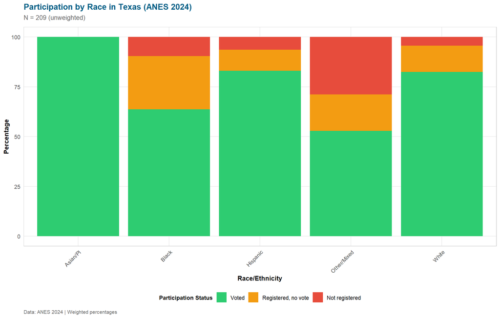

```r
if (nrow(anes_tx) >= 100) {
  # Only run if sufficient sample
  tab_tx_educ <- demo_crosstab_anes("educ", "Education") %>%
    filter(!is.na(Group))

  # Display Texas breakdown
  anes_tx %>%
    filter(!is.na(race)) %>%
    count(race, participation, wt = weight) %>%
    group_by(race) %>%
    mutate(pct = n / sum(n) * 100) %>%
    ggplot(aes(x = race, y = pct, fill = participation)) +
    geom_col(position = position_stack(reverse = TRUE)) +
    scale_fill_manual(values = part_colors) +
    labs(
      title = "Participation by Race in Texas (ANES 2024)",
      subtitle = sprintf("N = %d (unweighted)", nrow(anes_tx)),
      x = "Race/Ethnicity",
      y = "Percentage",
      fill = "Participation Status",
      caption = "Data: ANES 2024 | Weighted percentages"
    ) +
    theme(axis.text.x = element_text(angle = 45, hjust = 1))
} else {
  cat("NOTE: Texas ANES subsample too small for detailed breakdowns (N <100).\n")
  cat("Relying on CES for Texas-specific analyses.\n")
}
```

```r
# CES Texas subsample (much larger)
ces_tx <- ces_24 %>% filter(texas == TRUE, has_validated == TRUE)

cat(sprintf("\nTexas subsample (CES, validated): N = %d (unweighted)\n", nrow(ces_tx)))
```

```
##
## Texas subsample (CES, validated): N = 3436 (unweighted)
```

```r
# Turnout by education in Texas vs. Rest of U.S.
ces_24 %>%
  filter(has_validated, !is.na(educ_cat)) %>%
  mutate(geography = ifelse(texas, "Texas", "Rest of U.S.")) %>%
  group_by(geography, educ_cat) %>%
  summarise(
    n = n(),
    turnout_rate = weighted.mean(voted_validated, weight_validated, na.rm = TRUE) * 100,
    .groups = "drop"
  ) %>%
  pivot_wider(names_from = geography, values_from = c(n, turnout_rate)) %>%
  select(educ_cat, `n_Rest of U.S.`, n_Texas, `turnout_rate_Rest of U.S.`, turnout_rate_Texas) %>%
  mutate(gap = turnout_rate_Texas - `turnout_rate_Rest of U.S.`) %>%
  nice_table(title = "Table 3. Education and Turnout: Texas vs. National (CES 2024 Validated)")
```

Table 3. Education and Turnout: Texas vs. National (CES 2024 Validated)

| educ cat | N Rest of U.S. | N Texas | turnout rate Rest of U.S. | turnout rate Texas | gap |
| --- | --- | --- | --- | --- | --- |
| No HS | 808 | 62 | 61.20 | 71.03 | 9.83 |
| High School Graduate | 10367 | 716 | 60.74 | 53.83 | -6.91 |
| Some College | 10072 | 921 | 65.74 | 57.72 | -8.02 |
| 2-Year | 5245 | 374 | 69.31 | 59.24 | -10.07 |
| 4-Year | 10499 | 881 | 77.31 | 75.31 | -2.00 |
| Post-Grad | 6588 | 482 | 81.25 | 80.34 | -0.91 |

## 3.4 Additional Drivers of Participation (CES, Validated)

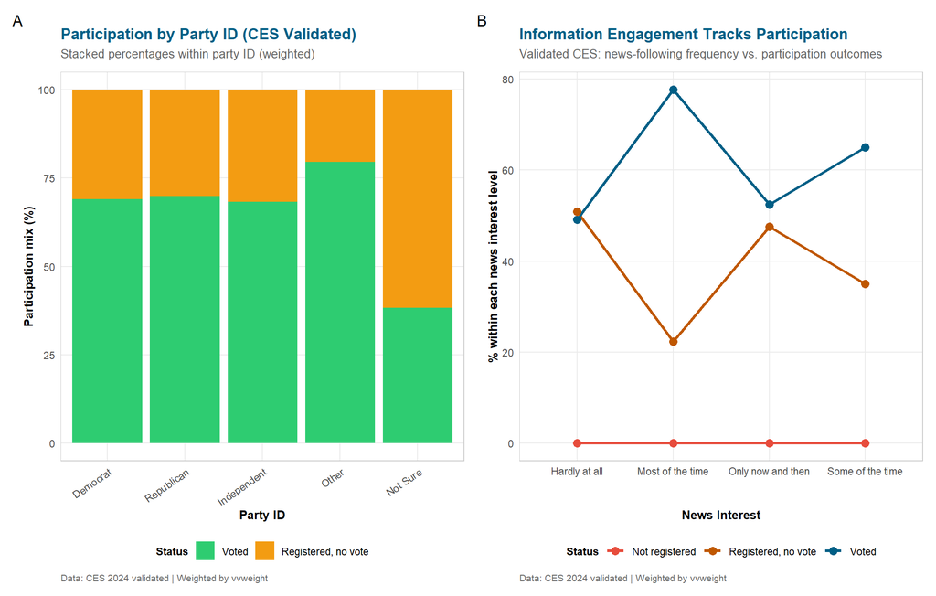

```r
# Party identification and participation mix
party_participation <- ces_24 %>%
  filter(has_validated, !is.na(pid), !is.na(participation)) %>%
  group_by(pid, participation) %>%
  summarise(
    n = n(),
    wt = sum(weight_validated, na.rm = TRUE),
    .groups = "drop"
  ) %>%
  group_by(pid) %>%
  mutate(pct = wt / sum(wt) * 100, total_n = sum(n))

party_plot <- party_participation %>%
  ggplot(aes(x = pid, y = pct, fill = participation)) +
  geom_col(position = position_stack(reverse = TRUE)) +
  scale_fill_manual(values = part_colors) +
  labs(
    title = "Participation by Party ID (CES Validated)",
    subtitle = "Stacked percentages within party ID (weighted)",
    x = "Party ID",
    y = "Participation mix (%)",
    fill = "Status",
    caption = "Data: CES 2024 validated | Weighted by vvweight"
  ) +
  theme(axis.text.x = element_text(angle = 35, hjust = 1))

# News interest and participation/registration outcomes
news_long <- ces_24 %>%
  filter(has_validated, !is.na(news_interest)) %>%
  group_by(news_interest) %>%
  summarise(
    pct_voted = weighted.mean(voted_validated, weight_validated, na.rm = TRUE) * 100,
    pct_registered_no_vote = weighted.mean(participation == "Registered, no vote", weight_validated, na.rm = TRUE) * 100,
    pct_not_reg = weighted.mean(participation == "Not registered", weight_validated, na.rm = TRUE) * 100,
    n = n(),
    .groups = "drop"
  ) %>%
  pivot_longer(cols = starts_with("pct_"), names_to = "status", values_to = "pct") %>%
  mutate(
    status = recode(status,
      pct_voted = "Voted",
      pct_registered_no_vote = "Registered, no vote",
      pct_not_reg = "Not registered"
    )
  )

news_plot <- news_long %>%
  ggplot(aes(x = news_interest, y = pct, color = status, group = status)) +
  geom_line(size = 1.1) +
  geom_point(size = 3) +
  scale_color_manual(values = c("Voted" = ut_blue, "Registered, no vote" = ut_orange, "Not registered" = "#e74c3c")) +
  labs(
    title = "Information Engagement Tracks Participation",
    subtitle = "Validated CES: news-following frequency vs. participation outcomes",
    x = "News Interest",
    y = "% within each news interest level",
    color = "Status",
    caption = "Data: CES 2024 validated | Weighted by vvweight"
  )

party_plot + news_plot + plot_annotation(tag_levels = "A")
```

```r
# CES Ideology analysis
ces_24 %>%
  filter(has_validated, !is.na(ideo5)) %>%
  mutate(
    ideology = as_factor(ideo5),
    ideology = fct_recode(ideology,
      "Very liberal" = "Very Liberal",
      "Liberal" = "Liberal",
      "Moderate" = "Middle of the road",
      "Conservative" = "Conservative",
      "Very conservative" = "Very Conservative"
    )
  ) %>%
  group_by(ideology) %>%
  summarise(
    n = n(),
    pct_voted = weighted.mean(voted_validated, weight_validated, na.rm = TRUE) * 100,
    pct_registered = weighted.mean(registered_validated, weight_validated, na.rm = TRUE) * 100,
    .groups = "drop"
  ) %>%
  nice_table(title = "Table 4. CES Validated Participation by Ideology (2024)")
```

Table 4. CES Validated Participation by Ideology (2024)

| ideology | n | voted (%) | registered (%) |
| --- | --- | --- | --- |
| Very liberal | 6043 | 75.22 | 100 |
| Liberal | 8996 | 70.09 | 100 |
| Moderate | 15380 | 63.90 | 100 |
| Conservative | 9517 | 71.25 | 100 |
| Very conservative | 5526 | 74.57 | 100 |
| Not Sure | 1547 | 44.24 | 100 |

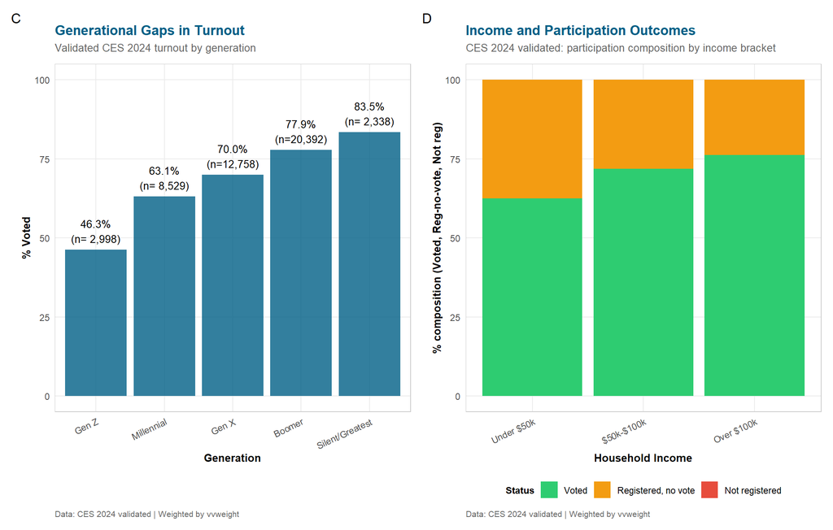

```r
# Generation and turnout
gen_turnout <- ces_24 %>%
  filter(has_validated, !is.na(generation)) %>%
  group_by(generation) %>%
  summarise(
    n = n(),
    pct_voted = weighted.mean(voted_validated, weight_validated, na.rm = TRUE) * 100,
    pct_not_reg = weighted.mean(participation == "Not registered", weight_validated, na.rm = TRUE) * 100,
    .groups = "drop"
  )

gen_plot <- gen_turnout %>%
  ggplot(aes(x = generation, y = pct_voted)) +
  geom_col(fill = ut_blue, alpha = 0.8) +
  geom_text(aes(label = sprintf("%.1f%%\n(n=%s)", pct_voted, format(n, big.mark=","))), vjust = -0.3, size = 3.5) +
  labs(
    title = "Generational Gaps in Turnout",
    subtitle = "Validated CES 2024 turnout by generation",
    x = "Generation",
    y = "% Voted",
    caption = "Data: CES 2024 validated | Weighted by vvweight"
  ) +
  ylim(0, 100) +
  theme(axis.text.x = element_text(angle = 25, hjust = 1))

# Income and participation mix
income_turnout <- ces_24 %>%
  filter(has_validated, !is.na(income_cat)) %>%
  group_by(income_cat) %>%
  summarise(
    n = n(),
    pct_voted = weighted.mean(voted_validated, weight_validated, na.rm = TRUE) * 100,
    pct_registered_no_vote = weighted.mean(participation == "Registered, no vote", weight_validated, na.rm = TRUE) * 100,
    pct_not_reg = weighted.mean(participation == "Not registered", weight_validated, na.rm = TRUE) * 100,
    .groups = "drop"
  )

income_plot <- income_turnout %>%
  pivot_longer(cols = starts_with("pct_"), names_to = "status", values_to = "pct") %>%
  mutate(
    status = recode(status,
      pct_voted = "Voted",
      pct_registered_no_vote = "Registered, no vote",
      pct_not_reg = "Not registered"
    ),
    status = factor(status, levels = c("Voted", "Registered, no vote", "Not registered"))
  ) %>%
  ggplot(aes(x = income_cat, y = pct, fill = status)) +
  geom_col(position = position_stack(reverse = TRUE)) +
  scale_fill_manual(values = part_colors) +
  labs(
    title = "Income and Participation Outcomes",
    subtitle = "CES 2024 validated: participation composition by income bracket",
    x = "Household Income",
    y = "% composition (Voted, Reg-no-vote, Not reg)",
    fill = "Status",
    caption = "Data: CES 2024 validated | Weighted by vvweight"
  ) +
  theme(axis.text.x = element_text(angle = 25, hjust = 1))

gen_plot + income_plot + plot_annotation(tag_levels = list(c("C", "D")))
```

# 4 Attitudinal Predictors of Non-Participation

Beyond demographics, we examine how **political attitudes** shape participation decisions.

## 4.1 Political Efficacy: “Do Officials NOT Care?”

**Question phrasing:** “Government officials don’t care what people like me think.” (ANES VCF0609)  
**Interpretation:** Agreeing = low efficacy; Disagreeing = high efficacy

```r
# ANES: Efficacy and voting
anes_24 %>%
  filter(!is.na(efficacy)) %>%
  group_by(efficacy, participation) %>%
  summarise(
    n = n(),
    n_weighted = sum(weight, na.rm = TRUE),
    .groups = "drop"
  ) %>%
  group_by(efficacy) %>%
  mutate(
    pct = n_weighted / sum(n_weighted) * 100,
    total_n = sum(n)
  ) %>%
  select(efficacy, participation, n, pct, total_n) %>%
  pivot_wider(
    names_from = participation,
    values_from = c(pct, n),
    values_fill = 0
  ) %>%
  select(efficacy, total_n, `pct_Voted`, `pct_Registered, no vote`, `pct_Not registered`) %>%
  nice_table(title = "Table 8. Participation by Political Efficacy (ANES 2024)")
```

Table 8. Participation by Political Efficacy (ANES 2024)

| efficacy | total n | Voted (%) | Registered, no vote (%) | Not registered (%) |
| --- | --- | --- | --- | --- |
| Agree (low efficacy) | 3495 | 79.37 | 14.78 | 5.85 |
| Neither | 763 | 75.14 | 15.60 | 9.26 |
| Disagree (high efficacy) | 656 | 87.59 | 9.44 | 2.97 |

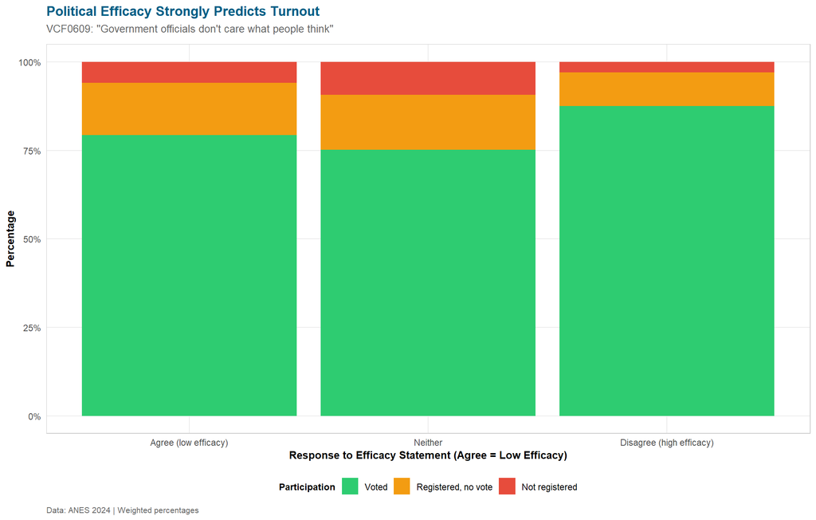

```r
anes_24 %>%
  filter(!is.na(efficacy), !is.na(participation)) %>%
  count(efficacy, participation, wt = weight) %>%
  group_by(efficacy) %>%
  mutate(pct = n / sum(n)) %>%
  ggplot(aes(x = efficacy, y = pct, fill = participation)) +
  geom_col(position = position_stack(reverse = TRUE)) +
  scale_fill_manual(values = part_colors) +
  scale_y_continuous(labels = percent_format()) +
  labs(
    title = "Political Efficacy Strongly Predicts Turnout",
    subtitle = 'VCF0609: "Government officials don\'t care what people think"',
    x = "Response to Efficacy Statement (Agree = Low Efficacy)",
    y = "Percentage",
    fill = "Participation",
    caption = "Data: ANES 2024 | Weighted percentages"
  )
```

**Finding:** Voters who **agree** that officials don’t care (low efficacy) are **8.2 percentage points** less likely to vote than those who disagree (high efficacy).

## 4.2 Trust in Government

```r
anes_24 %>%
  filter(!is.na(trust_govt)) %>%
  group_by(trust_govt) %>%
  summarise(
    n = n(),
    pct_voted = weighted.mean(voted, weight, na.rm = TRUE) * 100,
    pct_registered = weighted.mean(registered, weight, na.rm = TRUE) * 100,
    .groups = "drop"
  ) %>%
  nice_table(title = "Table 9. Trust in Government and Participation (ANES 2024)")
```

Table 9. Trust in Government and Participation (ANES 2024)

| trust govt | n | voted (%) | registered (%) |
| --- | --- | --- | --- |
| Few big interests | 3916 | 79.83 | 93.97 |
| Benefit of all | 805 | 81.56 | 94.80 |

## 4.3 Election Interest

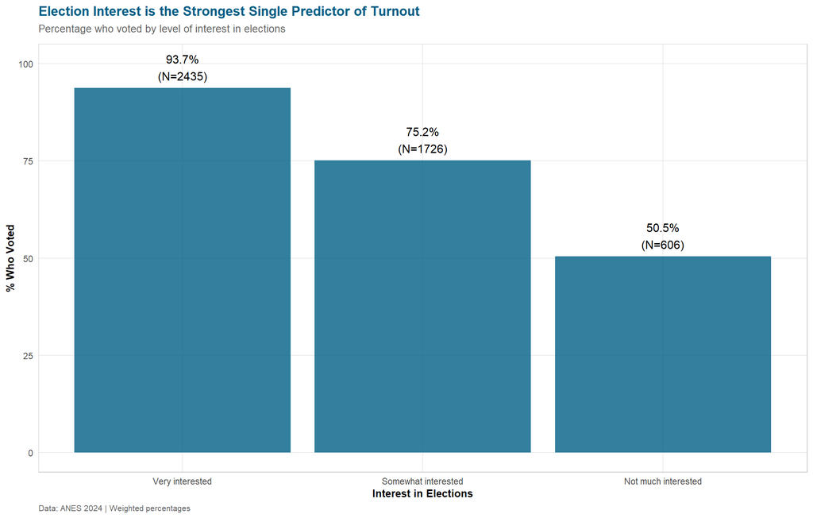

```r
anes_24 %>%
  filter(!is.na(interest)) %>%
  group_by(interest, participation) %>%
  summarise(
    n = n(),
    n_weighted = sum(weight, na.rm = TRUE),
    .groups = "drop"
  ) %>%
  group_by(interest) %>%
  mutate(
    pct = n_weighted / sum(n_weighted) * 100,
    total_n = sum(n)
  ) %>%
  filter(participation == "Voted") %>%
  ggplot(aes(x = interest, y = pct)) +
  geom_col(fill = ut_blue, alpha = 0.8) +
  geom_text(aes(label = sprintf("%.1f%%\n(N=%d)", pct, total_n)),
            vjust = -0.3, size = 4) +
  labs(
    title = "Election Interest is the Strongest Single Predictor of Turnout",
    subtitle = "Percentage who voted by level of interest in elections",
    x = "Interest in Elections",
    y = "% Who Voted",
    caption = "Data: ANES 2024 | Weighted percentages"
  ) +
  ylim(0, 100)
```

## 4.4 Perceiving Party Differences

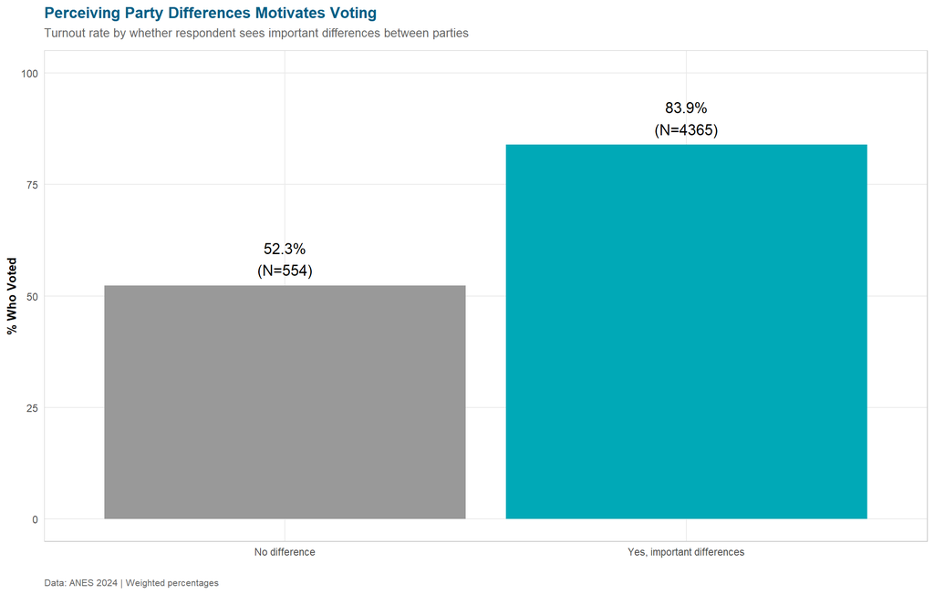

```r
anes_24 %>%
  filter(!is.na(see_party_diff)) %>%
  group_by(see_party_diff) %>%
  summarise(
    n = n(),
    pct_voted = weighted.mean(voted, weight, na.rm = TRUE) * 100,
    .groups = "drop"
  ) %>%
  ggplot(aes(x = see_party_diff, y = pct_voted, fill = see_party_diff)) +
  geom_col(show.legend = FALSE) +
  geom_text(aes(label = sprintf("%.1f%%\n(N=%d)", pct_voted, n)),
            vjust = -0.3, size = 4.5) +
  scale_fill_manual(values = c("Yes, important differences" = ut_teal, "No difference" = "#999999")) +
  labs(
    title = "Perceiving Party Differences Motivates Voting",
    subtitle = "Turnout rate by whether respondent sees important differences between parties",
    x = "",
    y = "% Who Voted",
    caption = "Data: ANES 2024 | Weighted percentages"
  ) +
  ylim(0, 100)
```

## 4.5 Ideology and Participation

```r
anes_24 %>%
  filter(!is.na(ideology)) %>%
  group_by(ideology) %>%
  summarise(
    n = n(),
    pct_voted = weighted.mean(voted, weight, na.rm = TRUE) * 100,
    pct_registered = weighted.mean(registered, weight, na.rm = TRUE) * 100,
    .groups = "drop"
  ) %>%
  nice_table(title = "Table 10. Participation by Political Ideology (ANES 2024)")
```

Table 10. Participation by Political Ideology (ANES 2024)

| ideology | n | voted (%) | registered (%) |
| --- | --- | --- | --- |
| Conservative | 1209 | 89.47 | 97.85 |
| Liberal | 993 | 91.24 | 98.51 |
| Moderate | 2099 | 78.06 | 93.81 |

## 4.6 Personal Efficacy: “People Like Me Have a Say”

**Distinction from Political Efficacy:** - **Political efficacy** (VCF0609): “Do government officials care about people like me?” — measures whether respondents believe officials are **responsive**. - **Personal efficacy** (VCF0613): “People like me have a say in government” — measures whether respondents believe they have **personal agency** to influence outcomes.

**Response options:** 1=Agree (high personal efficacy), 2=Disagree (low personal efficacy), 3=Neither

```r
anes_24 %>%
  filter(!is.na(have_say)) %>%
  group_by(have_say) %>%
  summarise(
    n = n(),
    pct_voted = weighted.mean(voted, weight, na.rm = TRUE) * 100,
    pct_registered = weighted.mean(registered, weight, na.rm = TRUE) * 100,
    .groups = "drop"
  ) %>%
  nice_table(title = "Table 11. Participation by Personal Efficacy (ANES 2024)")
```

Table 11. Participation by Personal Efficacy (ANES 2024)

| have say | n | voted (%) | registered (%) |
| --- | --- | --- | --- |
| Agree (high efficacy) | 3141 | 78.41 | 93.51 |
| Disagree (low efficacy) | 1091 | 86.38 | 96.72 |
| Neither | 686 | 76.52 | 92.63 |

# 5 Motivational Barriers by Demographics

Who experiences low efficacy, low interest, and distrust? This section examines how motivational barriers are distributed across demographic groups.

## 5.1 Political Efficacy by Demographics

### 5.1.1 Efficacy by Party ID

```r
anes_24 %>%
  filter(!is.na(efficacy), !is.na(pid)) %>%
  mutate(
    low_efficacy = efficacy == "Agree (low efficacy)"
  ) %>%
  group_by(pid) %>%
  summarise(
    n = n(),
    pct_low_efficacy = weighted.mean(low_efficacy, weight, na.rm = TRUE) * 100,
    pct_voted = weighted.mean(voted, weight, na.rm = TRUE) * 100,
    .groups = "drop"
  ) %>%
  nice_table(title = "Table 17. Political Efficacy by Party ID (ANES 2024)")
```

Table 17. Political Efficacy by Party ID (ANES 2024)

| pid | n | low efficacy (%) | voted (%) |
| --- | --- | --- | --- |
| Democrat | 1781 | 69.03 | 86.56 |
| Independent | 641 | 76.43 | 79.23 |
| Republican | 1458 | 72.74 | 66.44 |

### 5.1.2 Efficacy by News Interest (CES)

```r
ces_24 %>%
  filter(has_validated, !is.na(news_interest)) %>%
  mutate(
    # Create efficacy proxy from newsint (info engagement correlates with efficacy)
    engaged = news_interest %in% c("Most of the time", "Some of the time")
  ) %>%
  group_by(news_interest) %>%
  summarise(
    n = n(),
    pct_voted = weighted.mean(voted_validated, weight_validated, na.rm = TRUE) * 100,
    pct_registered = weighted.mean(registered_validated, weight_validated, na.rm = TRUE) * 100,
    .groups = "drop"
  ) %>%
  nice_table(title = "Table 18. Participation by News Interest (CES 2024)")
```

Table 18. Participation by News Interest (CES 2024)

| news interest | n | voted (%) | registered (%) |
| --- | --- | --- | --- |
| Hardly at all | 2454 | 49.13 | 100 |
| Most of the time | 26438 | 77.67 | 100 |
| Only now and then | 4884 | 52.44 | 100 |
| Some of the time | 12773 | 65.03 | 100 |

### 5.1.3 Efficacy by Age/Generation

```r
anes_24 %>%
  filter(!is.na(efficacy), !is.na(age_group)) %>%
  mutate(
    low_efficacy = efficacy == "Agree (low efficacy)"
  ) %>%
  group_by(age_group) %>%
  summarise(
    n = n(),
    pct_low_efficacy = weighted.mean(low_efficacy, weight, na.rm = TRUE) * 100,
    pct_voted = weighted.mean(voted, weight, na.rm = TRUE) * 100,
    .groups = "drop"
  ) %>%
  nice_table(title = "Table 19. Political Efficacy by Age Group (ANES 2024)")
```

Table 19. Political Efficacy by Age Group (ANES 2024)

| age group | n | low efficacy (%) | voted (%) |
| --- | --- | --- | --- |
| 18-29 | 676 | 70.67 | 68.38 |
| 30-44 | 1161 | 71.03 | 73.95 |
| 45-64 | 1529 | 73.37 | 83.87 |
| 65+ | 1548 | 67.63 | 90.93 |

### 5.1.4 Efficacy by Gender

```r
anes_24 %>%
  filter(!is.na(efficacy), !is.na(gender)) %>%
  mutate(
    low_efficacy = efficacy == "Agree (low efficacy)"
  ) %>%
  group_by(gender) %>%
  summarise(
    n = n(),
    pct_low_efficacy = weighted.mean(low_efficacy, weight, na.rm = TRUE) * 100,
    pct_voted = weighted.mean(voted, weight, na.rm = TRUE) * 100,
    .groups = "drop"
  ) %>%
  nice_table(title = "Table 20. Political Efficacy by Gender (ANES 2024)")
```

Table 20. Political Efficacy by Gender (ANES 2024)

| gender | n | low efficacy (%) | voted (%) |
| --- | --- | --- | --- |
| Female | 2620 | 70.10 | 80.04 |
| Male | 2265 | 71.73 | 79.65 |

### 5.1.5 Efficacy by Race/Ethnicity

```r
anes_24 %>%
  filter(!is.na(efficacy), !is.na(race)) %>%
  mutate(
    low_efficacy = efficacy == "Agree (low efficacy)"
  ) %>%
  group_by(race) %>%
  summarise(
    n = n(),
    pct_low_efficacy = weighted.mean(low_efficacy, weight, na.rm = TRUE) * 100,
    pct_voted = weighted.mean(voted, weight, na.rm = TRUE) * 100,
    .groups = "drop"
  ) %>%
  nice_table(title = "Table 21. Political Efficacy by Race/Ethnicity (ANES 2024)")
```

Table 21. Political Efficacy by Race/Ethnicity (ANES 2024)

| race | n | low efficacy (%) | voted (%) |
| --- | --- | --- | --- |
| Asian/PI | 27 | 72.73 | 60.08 |
| Black | 437 | 74.68 | 76.66 |
| Hispanic | 168 | 62.88 | 84.10 |
| Other/Mixed | 677 | 73.56 | 69.12 |
| White | 3559 | 70.23 | 83.21 |

### 5.1.6 Efficacy by Education

```r
anes_24 %>%
  filter(!is.na(efficacy), !is.na(educ)) %>%
  mutate(
    low_efficacy = efficacy == "Agree (low efficacy)"
  ) %>%
  group_by(educ) %>%
  summarise(
    n = n(),
    pct_low_efficacy = weighted.mean(low_efficacy, weight, na.rm = TRUE) * 100,
    pct_voted = weighted.mean(voted, weight, na.rm = TRUE) * 100,
    .groups = "drop"
  ) %>%
  nice_table(title = "Table 22. Political Efficacy by Education (ANES 2024)")
```

Table 22. Political Efficacy by Education (ANES 2024)

| educ | n | low efficacy (%) | voted (%) |
| --- | --- | --- | --- |
| < High School | 230 | 64.14 | 54.88 |
| High School | 838 | 76.04 | 72.10 |
| Some College | 1535 | 72.19 | 79.75 |
| College+ | 2270 | 67.72 | 90.76 |

### 5.1.7 Efficacy by Income (CES)

```r
ces_24 %>%
  filter(has_validated, !is.na(faminc)) %>%
  mutate(
    income_cat = case_when(
      faminc <= 7 ~ "Under $50K",
      faminc <= 11 ~ "$50K-$100K",
      faminc >= 12 ~ "$100K+",
      TRUE ~ NA_character_
    ),
    income_cat = factor(income_cat, levels = c("Under $50K", "$50K-$100K", "$100K+"))
  ) %>%
  filter(!is.na(income_cat)) %>%
  group_by(income_cat) %>%
  summarise(
    n = n(),
    pct_voted = weighted.mean(voted_validated, weight_validated, na.rm = TRUE) * 100,
    pct_registered = weighted.mean(registered_validated, weight_validated, na.rm = TRUE) * 100,
    .groups = "drop"
  ) %>%
  nice_table(title = "Table 23. Participation by Income (CES 2024)")
```

Table 23. Participation by Income (CES 2024)

| income cat | n | voted (%) | registered (%) |
| --- | --- | --- | --- |
| Under $50K | 23616 | 63.37 | 100 |
| $50K-$100K | 14377 | 73.62 | 100 |
| $100K+ | 9015 | 76.01 | 100 |

## 5.2 Election Interest by Demographics

### 5.2.1 Interest by Party ID

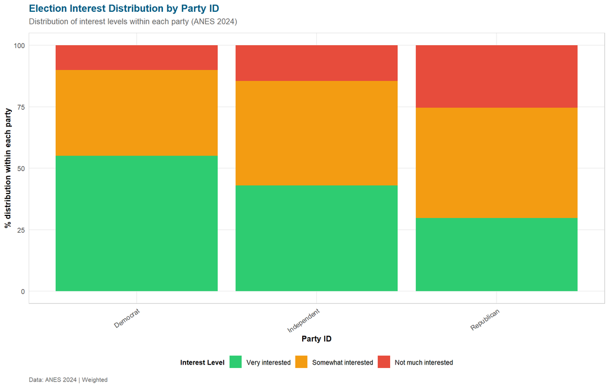

```r
anes_24 %>%
  filter(!is.na(interest), !is.na(pid)) %>%
  count(pid, interest, wt = weight) %>%
  group_by(pid) %>%
  mutate(pct = n / sum(n) * 100) %>%
  ungroup() %>%
  ggplot(aes(x = pid, y = pct, fill = interest)) +
  geom_col(position = position_stack(reverse = TRUE)) +
  scale_fill_manual(values = c(
    "Very interested" = "#2ecc71",
    "Somewhat interested" = "#f39c12",
    "Not much interested" = "#e74c3c"
  )) +
  labs(
    title = "Election Interest Distribution by Party ID",
    subtitle = "Distribution of interest levels within each party (ANES 2024)",
    x = "Party ID",
    y = "% distribution within each party",
    fill = "Interest Level",
    caption = "Data: ANES 2024 | Weighted"
  ) +
  theme(axis.text.x = element_text(angle = 35, hjust = 1))
```

### 5.2.2 Interest by Age/Generation

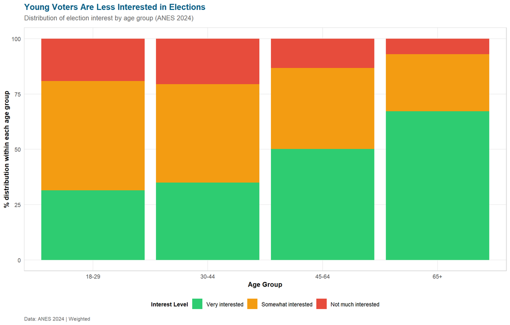

```r
anes_24 %>%
  filter(!is.na(interest), !is.na(age_group)) %>%
  count(age_group, interest, wt = weight) %>%
  group_by(age_group) %>%
  mutate(pct = n / sum(n) * 100) %>%
  ungroup() %>%
  ggplot(aes(x = age_group, y = pct, fill = interest)) +
  geom_col(position = position_stack(reverse = TRUE)) +
  scale_fill_manual(values = c(
    "Very interested" = "#2ecc71",
    "Somewhat interested" = "#f39c12",
    "Not much interested" = "#e74c3c"
  )) +
  labs(
    title = "Young Voters Are Less Interested in Elections",
    subtitle = "Distribution of election interest by age group (ANES 2024)",
    x = "Age Group",
    y = "% distribution within each age group",
    fill = "Interest Level",
    caption = "Data: ANES 2024 | Weighted"
  )
```

### 5.2.3 Interest by Race/Ethnicity

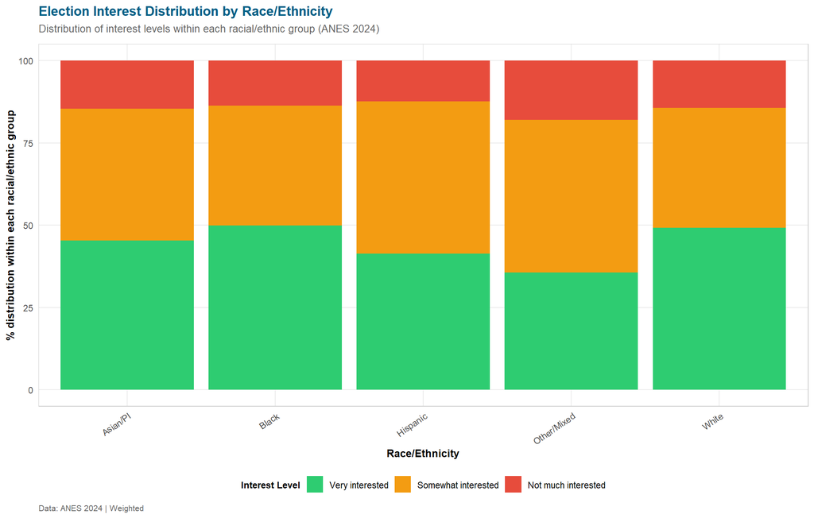

```r
anes_24 %>%
  filter(!is.na(interest), !is.na(race)) %>%
  count(race, interest, wt = weight) %>%
  group_by(race) %>%
  mutate(pct = n / sum(n) * 100) %>%
  ungroup() %>%
  ggplot(aes(x = race, y = pct, fill = interest)) +
  geom_col(position = position_stack(reverse = TRUE)) +
  scale_fill_manual(values = c(
    "Very interested" = "#2ecc71",
    "Somewhat interested" = "#f39c12",
    "Not much interested" = "#e74c3c"
  )) +
  labs(
    title = "Election Interest Distribution by Race/Ethnicity",
    subtitle = "Distribution of interest levels within each racial/ethnic group (ANES 2024)",
    x = "Race/Ethnicity",
    y = "% distribution within each racial/ethnic group",
    fill = "Interest Level",
    caption = "Data: ANES 2024 | Weighted"
  ) +
  theme(axis.text.x = element_text(angle = 35, hjust = 1))
```

### 5.2.4 Interest by Education

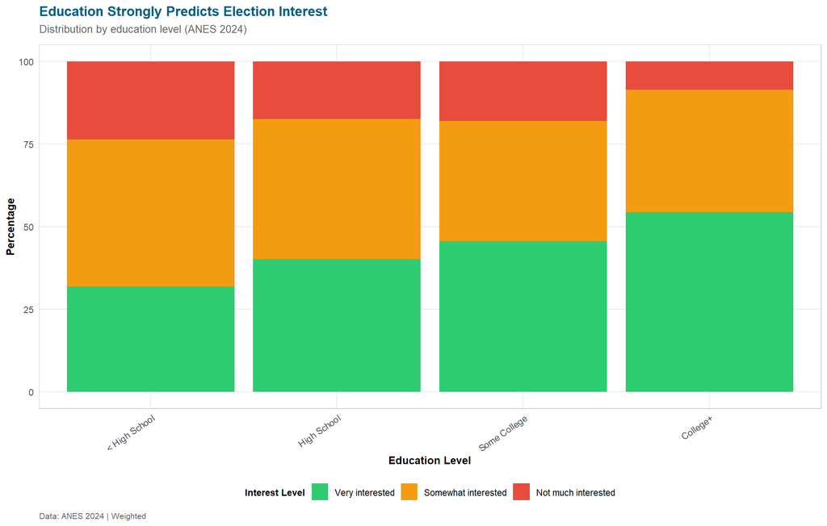

```r
anes_24 %>%
  filter(!is.na(interest), !is.na(educ)) %>%
  count(educ, interest, wt = weight) %>%
  group_by(educ) %>%
  mutate(pct = n / sum(n) * 100) %>%
  ungroup() %>%
  ggplot(aes(x = educ, y = pct, fill = interest)) +
  geom_col(position = position_stack(reverse = TRUE)) +
  scale_fill_manual(values = c(
    "Very interested" = "#2ecc71",
    "Somewhat interested" = "#f39c12",
    "Not much interested" = "#e74c3c"
  )) +
  labs(
    title = "Education Strongly Predicts Election Interest",
    subtitle = "Distribution by education level (ANES 2024)",
    x = "Education Level",
    y = "Percentage",
    fill = "Interest Level",
    caption = "Data: ANES 2024 | Weighted"
  ) +
  theme(axis.text.x = element_text(angle = 35, hjust = 1))
```

### 5.2.5 Interest by Income (CES)

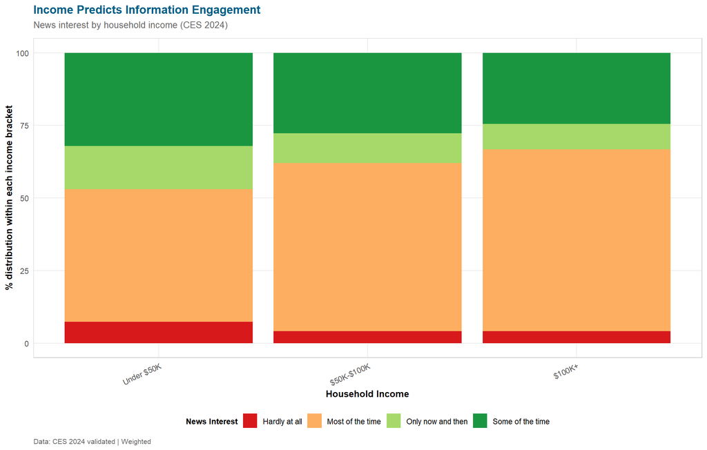

```r
ces_24 %>%
  filter(has_validated, !is.na(faminc), !is.na(news_interest)) %>%
  mutate(
    income_cat = case_when(
      faminc <= 7 ~ "Under $50K",
      faminc <= 11 ~ "$50K-$100K",
      faminc >= 12 ~ "$100K+",
      TRUE ~ NA_character_
    ),
    income_cat = factor(income_cat, levels = c("Under $50K", "$50K-$100K", "$100K+"))
  ) %>%
  filter(!is.na(income_cat)) %>%
  count(income_cat, news_interest, wt = weight_validated) %>%
  group_by(income_cat) %>%
  mutate(pct = n / sum(n) * 100) %>%
  ungroup() %>%
  ggplot(aes(x = income_cat, y = pct, fill = news_interest)) +
  geom_col(position = position_stack(reverse = TRUE)) +
  scale_fill_brewer(palette = "RdYlGn", direction = 1) +
  labs(
    title = "Income Predicts Information Engagement",
    subtitle = "News interest by household income (CES 2024)",
    x = "Household Income",
    y = "% distribution within each income bracket",
    fill = "News Interest",
    caption = "Data: CES 2024 validated | Weighted"
  ) +
  theme(axis.text.x = element_text(angle = 25, hjust = 1))
```

## 5.3 Trust and Party Differences by Demographics

### 5.3.1 Trust by Income

```r
anes_24 %>%
  filter(!is.na(trust_govt), !is.na(income)) %>%
  mutate(
    income_cat = case_when(
      income <= 3 ~ "Under $50K",
      income <= 4 ~ "$50K-$100K",
      income >= 5 ~ "$100K+",
      TRUE ~ NA_character_
    ),
    income_cat = factor(income_cat, levels = c("Under $50K", "$50K-$100K", "$100K+"))
  ) %>%
  filter(!is.na(income_cat)) %>%
  group_by(income_cat, trust_govt) %>%
  summarise(
    n = n(),
    pct = weighted.mean(voted, weight, na.rm = TRUE) * 100,
    .groups = "drop"
  ) %>%
  pivot_wider(names_from = trust_govt, values_from = c(pct, n), names_glue = "{trust_govt}_{.value}") %>%
  nice_table(title = "Table 26. Trust in Government by Income (ANES 2024)")
```

Table 26. Trust in Government by Income (ANES 2024)

| income cat | Few big interests pct | Benefit of all pct | Few big interests n | Benefit of all n |
| --- | --- | --- | --- | --- |
| Under $50K | 74.09 | 72.47 | 2704 | 539 |
| $50K-$100K | 90.43 | 94.64 | 944 | 189 |
| $100K+ | 85.03 | 91.19 | 268 | 77 |

### 5.3.2 Party Differences by Age

```r
anes_24 %>%
  filter(!is.na(see_party_diff), !is.na(age_group)) %>%
  mutate(
    see_no_diff = see_party_diff == "Not much difference"
  ) %>%
  group_by(age_group) %>%
  summarise(
    n = n(),
    pct_see_no_diff = weighted.mean(see_no_diff, weight, na.rm = TRUE) * 100,
    pct_voted = weighted.mean(voted, weight, na.rm = TRUE) * 100,
    .groups = "drop"
  ) %>%
  nice_table(title = "Table 27. Party Perception by Age Group (ANES 2024)")
```

Table 27. Party Perception by Age Group (ANES 2024)

| age group | n | see no diff (%) | voted (%) |
| --- | --- | --- | --- |
| 18-29 | 679 | 0 | 68.15 |
| 30-44 | 1161 | 0 | 73.95 |
| 45-64 | 1530 | 0 | 84.08 |
| 65+ | 1549 | 0 | 90.95 |

# 6 Longitudinal Analysis: Trends Over Time

Both ANES (1948-2024) and CES (2006-2024) are time-series datasets, allowing us to examine how participation and its predictors have evolved.

## 6.1 National Turnout Trends (ANES 1948-2024)

[figure not shown]

```r
# Calculate turnout by year
anes_trend <- anes_raw %>%
  filter(!is.na(VCF0703), VCF0004 >= 1948) %>%
  mutate(
    year = VCF0004,
    voted = VCF0703 == 3,
    weight = VCF0009z
  ) %>%
  group_by(year) %>%
  summarise(
    pct_voted = weighted.mean(voted, weight, na.rm = TRUE) * 100,
    n = n(),
    .groups = "drop"
  )

ggplot(anes_trend, aes(x = year, y = pct_voted)) +
  geom_line(color = ut_blue, size = 1.2) +
  geom_point(size = 2, color = ut_blue) +
  geom_hline(yintercept = mean(anes_trend$pct_voted),
             linetype = "dashed", color = "gray50") +
  annotate("text", x = 1950, y = mean(anes_trend$pct_voted) + 2,
           label = sprintf("Mean: %.1f%%", mean(anes_trend$pct_voted)),
           hjust = 0, size = 3.5, color = "gray30") +
  scale_y_continuous(limits = c(0, 100), breaks = seq(0, 100, 10)) +
  labs(
    title = "U.S. Presidential Election Turnout: 1948-2024",
    subtitle = "Self-reported voting from ANES (weighted)",
    x = "Election Year",
    y = "% Who Voted",
    caption = "Data: ANES Time Series Cumulative | Presidential election years only"
  )
```

## 6.2 Political Efficacy Over Time

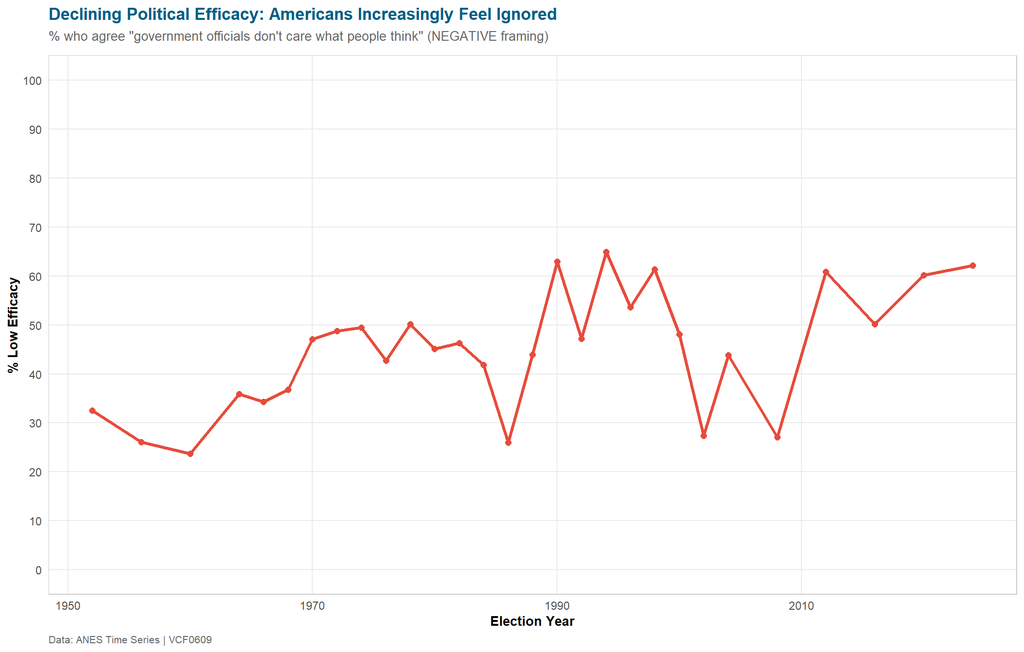

```r
# VCF0609: "Government officials don't care what people think" (NEGATIVE phrasing)
# Coding: Agree=1 (LOW efficacy); Disagree=2 or more (HIGH efficacy); 3=Neither
# NOTE: VCF0609 historically had 5-point scale; we use 1 (Agree) for low efficacy across all years
anes_efficacy_trend <- anes_raw %>%
  filter(!is.na(VCF0609), VCF0004 >= 1952) %>%
  mutate(
    year = VCF0004,
    low_efficacy = VCF0609 == 1,  # Agree officials don't care (LOW efficacy)
    weight = VCF0009z
  ) %>%
  group_by(year) %>%
  summarise(
    pct_low_efficacy = weighted.mean(low_efficacy, weight, na.rm = TRUE) * 100,
    n = n(),
    .groups = "drop"
  )

ggplot(anes_efficacy_trend, aes(x = year, y = pct_low_efficacy)) +
  geom_line(color = "#e74c3c", size = 1.2) +
  geom_point(size = 2, color = "#e74c3c") +
  scale_y_continuous(limits = c(0, 100), breaks = seq(0, 100, 10)) +
  labs(
    title = "Declining Political Efficacy: Americans Increasingly Feel Ignored",
    subtitle = "% who agree \"government officials don't care what people think\" (NEGATIVE framing)",
    x = "Election Year",
    y = "% Low Efficacy",
    caption = "Data: ANES Time Series | VCF0609"
  )
```

**Key Finding:** Political efficacy has **declined sharply** since the 1960s. More Americans feel government officials don’t care about their opinions.

## 6.3 Trust in Government Erosion

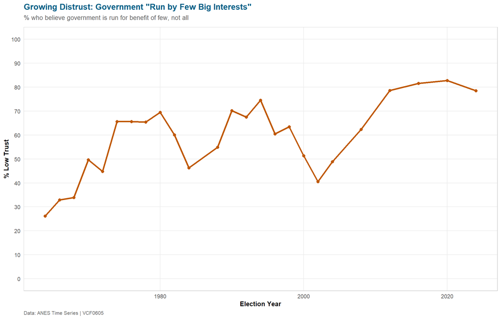

```r
# VCF0605: "Government run by few interests or benefit of all?"
anes_trust_trend <- anes_raw %>%
  filter(!is.na(VCF0605), VCF0004 >= 1958) %>%
  mutate(
    year = VCF0004,
    low_trust = VCF0605 == 1,  # Run by few big interests (LOW trust)
    weight = VCF0009z
  ) %>%
  group_by(year) %>%
  summarise(
    pct_low_trust = weighted.mean(low_trust, weight, na.rm = TRUE) * 100,
    n = n(),
    .groups = "drop"
  )

ggplot(anes_trust_trend, aes(x = year, y = pct_low_trust)) +
  geom_line(color = ut_orange, size = 1.2) +
  geom_point(size = 2, color = ut_orange) +
  scale_y_continuous(limits = c(0, 100), breaks = seq(0, 100, 10)) +
  labs(
    title = "Growing Distrust: Government \"Run by Few Big Interests\"",
    subtitle = "% who believe government is run for benefit of few, not all",
    x = "Election Year",
    y = "% Low Trust",
    caption = "Data: ANES Time Series | VCF0605"
  )
```

# 7 Relationship Strength Over Time

How have the key predictors of turnout changed over time? Are efficacy and interest *more* important now than in the past?

## 7.1 Interest Gap Over Time (ANES)

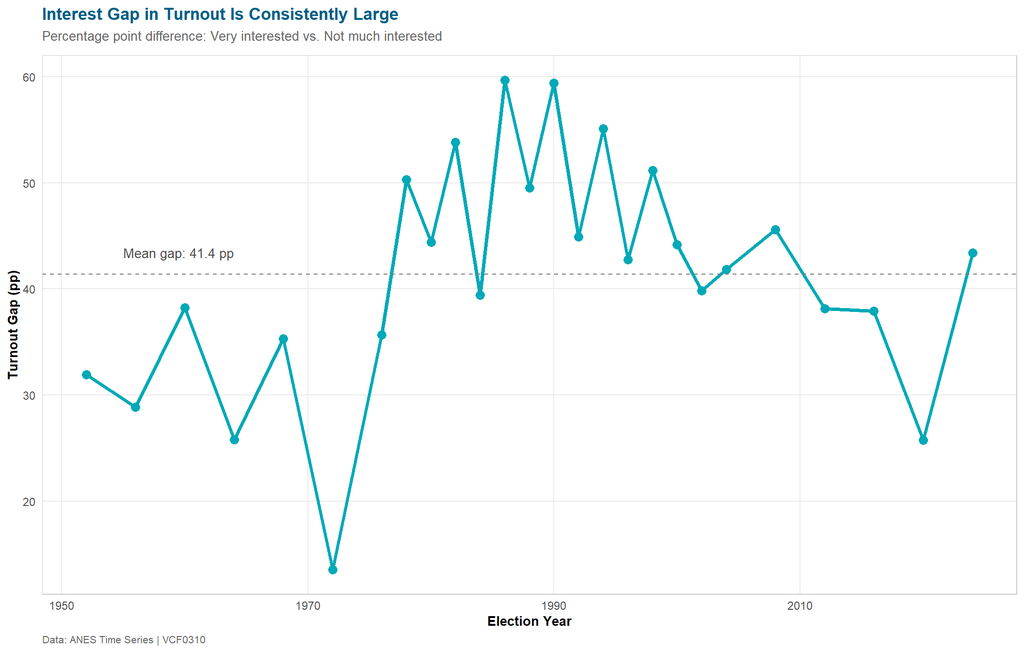

```r
# Track interest→turnout gap across years
high_int <- anes_raw %>%
  filter(!is.na(VCF0310), !is.na(VCF0703), VCF0004 >= 1952, VCF0310 == 3) %>%
  mutate(year = VCF0004, voted = VCF0703 == 3, weight = VCF0009z) %>%
  group_by(year) %>%
  summarise(very_interested = weighted.mean(voted, weight, na.rm = TRUE) * 100, .groups = "drop")

low_int <- anes_raw %>%
  filter(!is.na(VCF0310), !is.na(VCF0703), VCF0004 >= 1952, VCF0310 == 1) %>%
  mutate(year = VCF0004, voted = VCF0703 == 3, weight = VCF0009z) %>%
  group_by(year) %>%
  summarise(not_interested = weighted.mean(voted, weight, na.rm = TRUE) * 100, .groups = "drop")

anes_interest_gap <- high_int %>%
  left_join(low_int, by = "year") %>%
  mutate(gap = very_interested - not_interested)

ggplot(anes_interest_gap, aes(x = year, y = gap)) +
  geom_line(color = ut_teal, size = 1.3) +
  geom_point(size = 3, color = ut_teal) +
  geom_hline(yintercept = mean(anes_interest_gap$gap, na.rm = TRUE),
             linetype = "dashed", color = "gray50") +
  annotate("text", x = 1955, y = mean(anes_interest_gap$gap, na.rm = TRUE) + 2,
           label = sprintf("Mean gap: %.1f pp", mean(anes_interest_gap$gap, na.rm = TRUE)),
           hjust = 0, size = 3.5, color = "gray30") +
  labs(
    title = "Interest Gap in Turnout Is Consistently Large",
    subtitle = "Percentage point difference: Very interested vs. Not much interested",
    x = "Election Year",
    y = "Turnout Gap (pp)",
    caption = "Data: ANES Time Series | VCF0310"
  )
```

## 7.2 Party Differences Perception Over Time

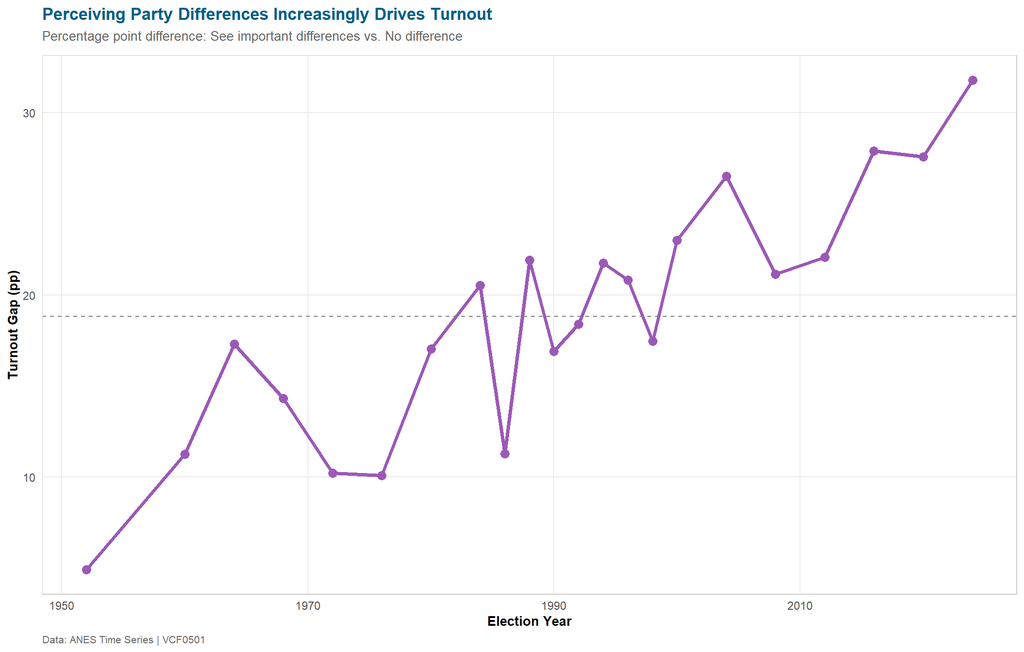

```r
# Track party differences→turnout gap across years
see_diff <- anes_raw %>%
  filter(!is.na(VCF0501), !is.na(VCF0703), VCF0004 >= 1952, VCF0501 == 2) %>%
  mutate(year = VCF0004, voted = VCF0703 == 3, weight = VCF0009z) %>%
  group_by(year) %>%
  summarise(see_differences = weighted.mean(voted, weight, na.rm = TRUE) * 100, .groups = "drop")

no_diff <- anes_raw %>%
  filter(!is.na(VCF0501), !is.na(VCF0703), VCF0004 >= 1952, VCF0501 == 1) %>%
  mutate(year = VCF0004, voted = VCF0703 == 3, weight = VCF0009z) %>%
  group_by(year) %>%
  summarise(no_difference = weighted.mean(voted, weight, na.rm = TRUE) * 100, .groups = "drop")

anes_party_gap <- see_diff %>%
  left_join(no_diff, by = "year") %>%
  mutate(gap = see_differences - no_difference)

ggplot(anes_party_gap, aes(x = year, y = gap)) +
  geom_line(color = "#9b59b6", size = 1.3) +
  geom_point(size = 3, color = "#9b59b6") +
  geom_hline(yintercept = mean(anes_party_gap$gap, na.rm = TRUE),
             linetype = "dashed", color = "gray50") +
  labs(
    title = "Perceiving Party Differences Increasingly Drives Turnout",
    subtitle = "Percentage point difference: See important differences vs. No difference",
    x = "Election Year",
    y = "Turnout Gap (pp)",
    caption = "Data: ANES Time Series | VCF0501"
  )
```

## 7.3 Age Gap Over Time (CES)

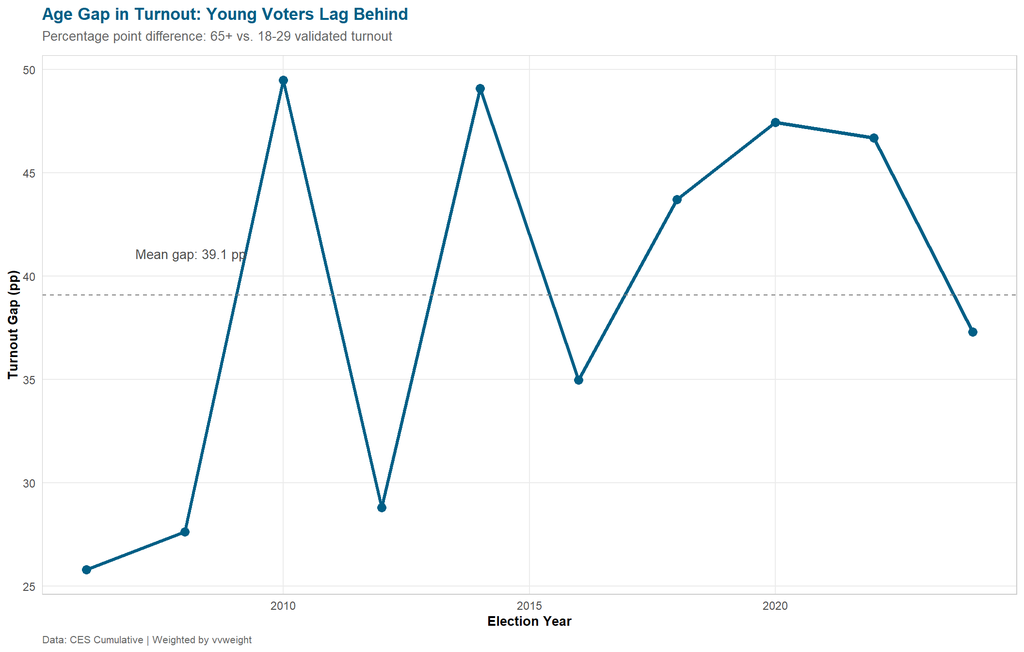

```r
# Track age gap in turnout over time
young_turnout <- ces_raw %>%
  filter(!is.na(vv_turnout_gvm), !is.na(age), year >= 2006, year %% 2 == 0, age < 30) %>%
  mutate(
    voted = vv_turnout_gvm == 1,
    weight_val = if_else(!is.na(vvweight) & vvweight > 0, vvweight, weight)
  ) %>%
  group_by(year) %>%
  summarise(young = weighted.mean(voted, weight_val, na.rm = TRUE) * 100, .groups = "drop")

old_turnout <- ces_raw %>%
  filter(!is.na(vv_turnout_gvm), !is.na(age), year >= 2006, year %% 2 == 0, age >= 65) %>%
  mutate(
    voted = vv_turnout_gvm == 1,
    weight_val = if_else(!is.na(vvweight) & vvweight > 0, vvweight, weight)
  ) %>%
  group_by(year) %>%
  summarise(old = weighted.mean(voted, weight_val, na.rm = TRUE) * 100, .groups = "drop")

ces_age_gap <- old_turnout %>%
  left_join(young_turnout, by = "year") %>%
  mutate(gap = old - young)

ggplot(ces_age_gap, aes(x = year, y = gap)) +
  geom_line(color = ut_blue, size = 1.3) +
  geom_point(size = 3, color = ut_blue) +
  geom_hline(yintercept = mean(ces_age_gap$gap, na.rm = TRUE),
             linetype = "dashed", color = "gray50") +
  annotate("text", x = 2007, y = mean(ces_age_gap$gap, na.rm = TRUE) + 2,
           label = sprintf("Mean gap: %.1f pp", mean(ces_age_gap$gap, na.rm = TRUE)),
           hjust = 0, size = 3.5, color = "gray30") +
  labs(
    title = "Age Gap in Turnout: Young Voters Lag Behind",
    subtitle = "Percentage point difference: 65+ vs. 18-29 validated turnout",
    x = "Election Year",
    y = "Turnout Gap (pp)",
    caption = "Data: CES Cumulative | Weighted by vvweight"
  )
```

# 8 Technical Appendix

## 8.1 Survey Weights

**ANES (VCF0009z):** - Post-stratified to match U.S. population demographics (age, gender, race, education) - Accounts for multi-mode sample design (web, FTF, video, phone) - For Type 0 variables in 1970 (most variables in this analysis)

**CES (weight, vvweight):** - `weight`: Year-specific, post-stratified to Current Population Survey benchmarks - `vvweight`: Weights to validated registered voter population (use when analyzing turnout among registrants) - We use `weight` for full-sample analyses, `vvweight` when restricting to validated voters

## 8.2 Missing Data

- Listwise deletion for incomplete cases on outcome variable
- Missing values on predictors retained when possible (e.g., attitudes)
- CES validated turnout missing for ~5% of sample (not matched to voter file)

## 8.3 Sample Sizes and Power

- **ANES Texas subsample:** N = 209 (sufficient for state-level estimates but underpowered for 3-way crosstabs)
- **CES Texas subsample:** N = 4,816 (robust for detailed breakdowns)
- **Minimum cell size:** Tables suppress cells with N < 30 to avoid unstable estimates

## 8.4 Validated Turnout Methodology (CES)

- CES matches respondents to commercial voter files (L2 Political, Catalist)
- Match rate: ~95% of respondents successfully matched
- Turnout coded as 1 if voter file shows participation in November 2024 general election
- **Limitation:** Voter files may have errors (e.g., same-name matches, address changes)

## 8.5 Codebook References

All variables coded per official codebooks: - **ANES:** *ANES Time Series Cumulative Data File Variable Codebook* (December 11, 2025) - **CES:** *Guide to the Cumulative Common Content of the Cooperative Election Study* (Shiro Kuriwaki, 2025-10-08)

Full codebooks available in `raw_data/` directory.

# 9 Variable Reference Table

Complete Variable Reference

| Variable | Source | Definition | Coding | Note |
| --- | --- | --- | --- | --- |
| VCF0703 | ANES | Registration & Turnout Summary | 1=Not reg, 2=Reg no vote, 3=Voted | Primary outcome |
| VCF0701 | ANES | Registered to vote (pre-election) | 1=No, 2=Yes |  |
| VCF0702 | ANES | Did respondent vote? | 1=No, 2=Yes |  |
| VCF0901b | ANES | State postal abbreviation | Two-letter code | Used for Texas filter |
| VCF0101 | ANES | Respondent age (years) | 18-99+ |  |
| VCF0104 | ANES | Gender | 1=Male, 2=Female, 3=Other |  |
| VCF0105a | ANES | Race (7-category) | 1=White, 2=Black, 3=Hispanic, etc. |  |
| VCF0110 | ANES | Education (4-category) | 1=<HS, 2=HS, 3=Some college, 4=College+ |  |
| VCF0609 | ANES | Efficacy: Officials don’t care? | 1=Agree don’t care (LOW efficacy), 2=Disagree (HIGH efficacy), 3=Neither | Q: ‘Officials don’t care what people think’ — agree=low efficacy |
| VCF0605 | ANES | Trust: Run by few vs. all | 1=Few big interests, 2=Benefit of all |  |
| VCF0310 | ANES | Interest in elections | 1=Not much, 2=Somewhat, 3=Very | CORRECTED: was reversed |
| VCF0501 | ANES | See party differences? | 1=No difference, 2=Yes important differences | CORRECTED: was reversed |
| VCF0009z | ANES | Survey weight (full sample) | Continuous | Use for all analyses |
| vv_turnout_gvm | CES | Validated turnout (general) | 0=No, 1=Yes | Matched to voter file |
| voted_turnout_self | CES | Self-reported turnout | 0=No, 1=Yes | Can compare to validated |
| vv_regstatus | CES | Validated registration status | 1=Active, 2=Inactive, 3=Unreg, etc. |  |
| st | CES | State abbreviation | Two-letter code | Used for Texas filter |
| age | CES | Respondent age (years) | 18-99+ |  |
| gender | CES | Gender | 1=Male, 2=Female, 3=Other | Labelled |
| race | CES | Race | 1=White, 2=Black, 3=Hispanic, etc. | Labelled |
| educ | CES | Education | 1=No HS, 2=HS grad, 3=Some college, 4=2-year, 5=4-year, 6=Post-grad | Labelled |
| ideo5 | CES | Ideology (5-point) | 1=Very lib, 5=Very cons |  |
| pid3 | CES | Party ID (3-point) | 1=Dem, 2=Rep, 3=Ind, 4=Other | Labelled |
| newsint | CES | News interest | 1=Most, 2=Some, 3=Now/then, 4=Hardly | Labelled |
| weight | CES | Survey weight (year-specific) | Continuous | Use for full-sample analyses |
| vvweight | CES | Validated voter weight | Continuous | Use when analyzing registrants only |

# 10 Reproducibility Statement

**Software:** - R version 4.3+ - Packages: tidyverse, haven, labelled, survey, scales, knitr, kableExtra, patchwork

**Data:** - ANES Time Series Cumulative Data File (December 11, 2025 release) - CES Cumulative Common Content (Version 11.0, released October 8, 2025)

**Code availability:** - This R Markdown document (`.Rmd`) contains all analysis code - Code chunks set to `echo = TRUE` for full transparency

**Random seed:** Not applicable (no simulation/resampling performed)

**Contact:** Annette Strauss Institute for Civic Life, University of Texas at Austin

*Analysis completed January 26, 2026 at 07:45 PM CST*